# Coursera Data Science Capstone Project

Dictionary Study

Samuel Bozzi Baco

## 0 LOAD PACKAGES

```r
library(tidyverse)
library(tidytext)
library(lexicon)
library(stringr)
library(textclean)
library(furrr)
library(stringi)
library(furrr)
library(data.table)
library(tidyr)
library(scales)
library(qdap)
library(SnowballC)
```

## 0 INTRODUCTION

This document presents an attempt for dictionary optimization, in order to determine the minimum amount of data necessary to create the final prediction model. Most part follows the suggestions from Dylan Tweed on https://rpubs.com/BreaizhZut/MilesStone_NgramPrediction, with the difference to use Tidy Text package as much as it possible.

## 1 DATA DOWNLOAD AND READING

The files were downloaded using a link available at Task 0 part of Coursera web site.

```r
fileLink <- "https://d396qusza40orc.cloudfront.net/dsscapstone/dataset/Coursera-SwiftKey.zip"

# Download raw data

download.file(url = fileLink,
              destfile = "dataset/rawData.zip")

# Extract the file

unzip("dataset/rawData.zip",
      exdir = "dataset")
```

The analysis will be focused on English language. The data from three sources (blogs, news and twitter) will be loaded at a list, to be transformed in a Corpus.

```r
setwd("~/R/Learning/Coursera/Course_10_Capstone")

# Import data

rawData <- list(blog = readLines("dataset/final/en_US/en_US.blogs.txt",
                                 warn = F,
                                 skipNul = T,
                                 encoding = "UTF-8"),
                news = readLines("dataset/final/en_US/en_US.news.txt",
                                 warn = F,
                                 skipNul = T,
                                 encoding = "UTF-8"),
                twitter = readLines(file("dataset/final/en_US/en_US.twitter.txt",
                                         open = "rb"),
                                    warn = F,
                                    skipNul = T,
                                    encoding = "UTF-8")
)

#closeAllConnections()
```

## 2 DATA SAMPLING AND CLANING

```r
sample_clean <- function(rawData, size = 0.1) {

  plan(multiprocess)

  rawData %>%
        future_map(function (z) {
          set.seed(123456)
          sample(z, size = (size*length(z)))}) %>%
        future_map(replace_contraction) %>%
        future_map(replace_hash) %>%
        future_map(replace_internet_slang) %>%
        future_map(replace_url) %>%
        future_map(replace_non_ascii) %>%
        future_map(replace_incomplete) %>%
        future_map(replace_emoticon) %>%
        # Replace accented characters
        future_map(stri_trans_general,
            id = "Latin-ASCII") %>%
        # remove consecutive duplicated words
        future_map(str_remove_all, pattern = "(\\b\\S+)(?:\\s+\\1\\b)+") %>%
        # remove all numbers
        future_map(str_remove_all, pattern = "\\d+") %>%
        # remove repeated words
        future_map(str_remove_all, pattern = "([[:alpha:]])\\1{2,}") %>%
        # remove underscores
        future_map(str_remove_all, pattern = "_") %>%
        future_map(as_tibble) %>%
        bind_rows(.id = "Source")

}

# Sample with 10% of the value.

rawSample10 <- sample_clean(rawData, size = 0.1)
```

In addition, the dataframe with profane words will be constructed, using all sources from *lexicon* package.

```r
# Create profane words tibble

profaneWords <-
        list(alvarez = toString(profanity_alvarez),
             arr_bad = toString(profanity_arr_bad),
             banned = toString(profanity_banned),
             racist = toString(profanity_racist),
             zac = toString(profanity_zac_anger)) %>%
        as_tibble() %>%
        gather(key = "lexicon") %>%
        unnest_tokens(word, value) %>%
        distinct(word, .keep_all = T)
```

## 3 COMPARING SOURCES

At this section, the three sources (blog, news and twitter) will be compared, first by word frequency, than using Zipf’s Law and tf-idf calculations. The framework can found at https://www.tidytextmining.com/index.html.

For the calculations, the 10% Sample will be used.

```r
unigram <-
        rawSample10 %>%
        unnest_tokens(word, value) %>%
        anti_join(profaneWords) %>%
        anti_join(stop_words) %>%
        mutate(word = wordStem(word, language = "english")) %>%
        count(Source, word, sort = T)


totalWords <-
        unigram %>%
        group_by(Source) %>%
        summarise(total = sum(n))

unigram <-
       left_join(unigram, totalWords) %>%
       mutate(p = n / total) %>%
       group_by(Source) %>%
       mutate(rank = row_number())

freq <-
       unigram %>%
       select(-rank, -n, -total) %>%
       spread(Source, p) %>%
       gather(Source, p, `news`:`twitter`)
```

With the word frequency, it is possible to plot the correlation between sources.

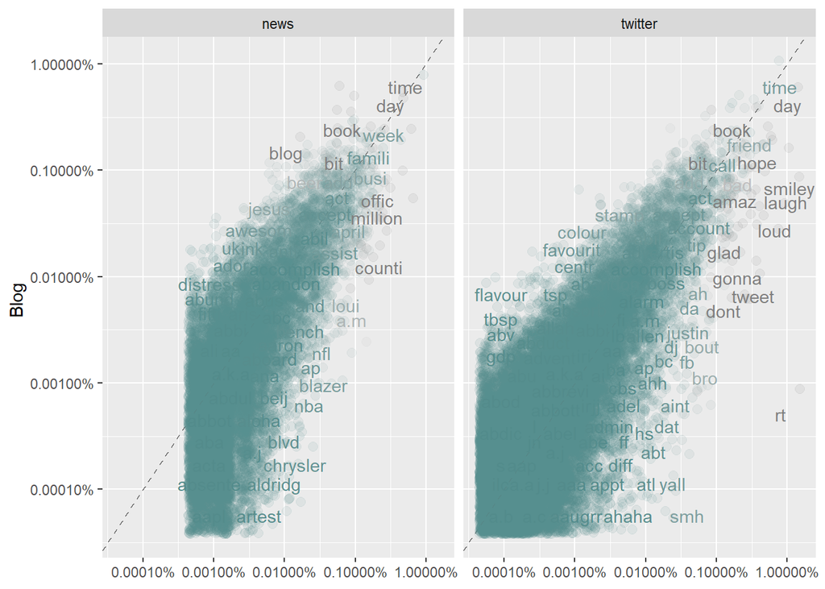

```r
ggplot(freq, aes(x = p, y = blog, color = abs(blog - p))) +
  geom_abline(color = "gray40", lty = 2) +
  geom_jitter(alpha = 0.1, size = 2.5, width = 0.3, height = 0.3) +
  geom_text(aes(label = word), check_overlap = TRUE, vjust = 1.5) +
  scale_x_log10(labels = percent_format()) +
  scale_y_log10(labels = percent_format()) +
  scale_color_gradient(limits = c(0, 0.001), low = "darkslategray4", high = "gray75") +
  facet_wrap(~Source, ncol = 2) +
  theme(legend.position="none") +
  labs(y = "Blog ", x = NULL)
```

With the tokenized data, it is possible to analyze the Zipf’s Law.

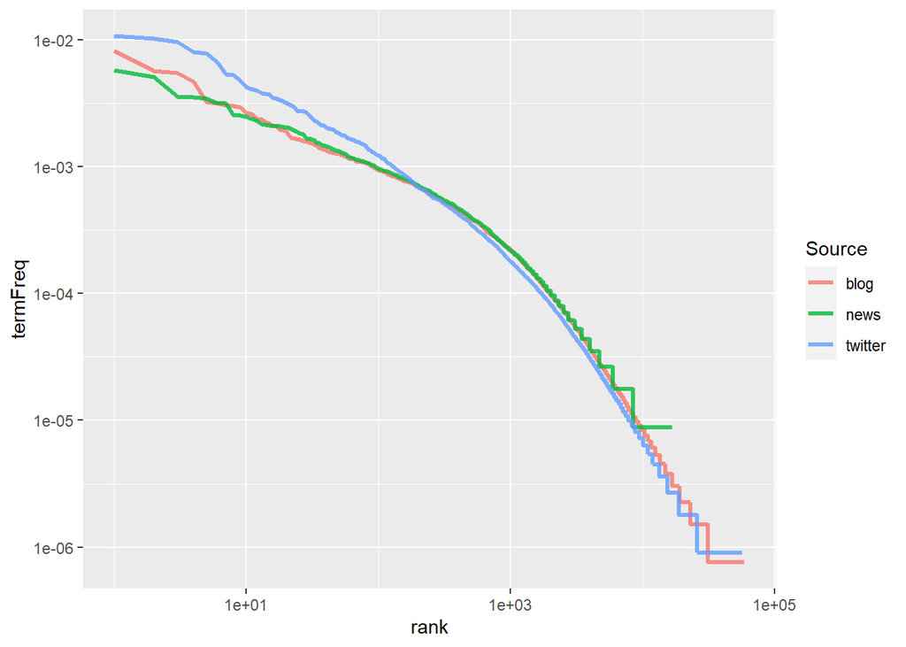

```r
freqRank <-
  unigram %>%
  group_by(Source) %>%
  mutate(rank = row_number(),
         `termFreq` = n/total)

freqRank %>%
  ggplot(aes(rank, `termFreq`, color = Source)) +
  geom_line(size = 1.1, alpha = 0.8, show.legend = T) +
  scale_x_log10() +
  scale_y_log10()
```

```r
rankSub <- freqRank %>%
  filter(rank < 1000,
         rank > 100)

pLaw <- lm(log10(termFreq) ~ log10(rank), data = rankSub)

pLaw
```

```
##
## Call:
## lm(formula = log10(termFreq) ~ log10(rank), data = rankSub)
##
## Coefficients:
## (Intercept)  log10(rank)
##     -1.4757      -0.7268
```

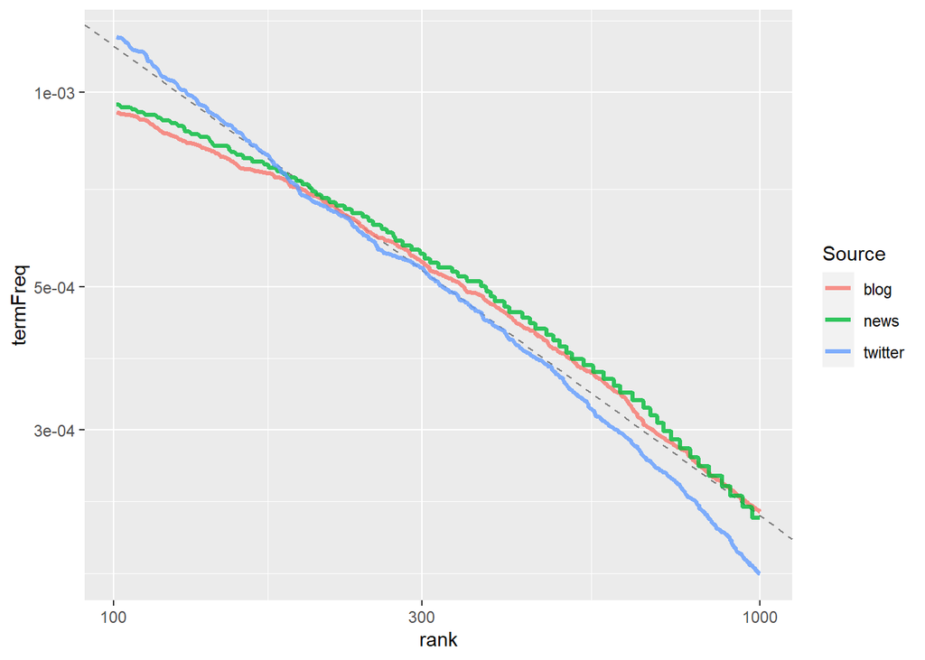

```r
rankSub %>%
  ggplot(aes(rank, termFreq, color = Source)) +
  geom_abline(intercept = pLaw$coefficients[[1]], slope = pLaw$coefficients[[2]], color = "gray50", linetype = 2) +
  geom_line(size = 1.1, alpha = 0.8, show.legend = TRUE) +
  scale_x_log10() +
  scale_y_log10()
```